# Capstone Study: Cyclistic

Guy Bartoli

1/14/2022

## Introduction

Welcome to my case study for Google’s Data Analytics Professional Certificate program. This document will go through the different stages of my analysis in the order of Ask, Prepare, Process, Analyze, Share, and Act.

### Scenario

You are a junior data analyst working in the marketing analyst team at Cyclistic, a bike-share company in Chicago. The director of marketing believes the company’s future success depends on maximizing the number of annual memberships. Therefore, your team wants to understand how casual riders and annual members use Cyclistic bikes differently. From these insights, your team will design a new marketing strategy to convert casual riders into annual members. But first, Cyclistic executives must approve your recommendations, so they must be backed up with compelling data insights and professional data visualizations.

## Ask

### What is the problem I am trying to solve?

Cyclistic wants to understand the different ways that customers use their bikes to help create an effective marketing strategy that targets casual riders to grow annual membership. Reviewing behaviors and trends of the customers will provide insights to what, how, and where they can appeal to casual riders to meet this goal.

- The business task is to identify trends in rider usage to market effectively to casual riders.
- How do annual members and casual riders use Cyclistic bikes differently?

## Prepare

The data has been made available by Motivate International Inc. under this [license](https://ride.divvybikes.com/data-license-agreement). For my analysis, I will be utilizing data for January through December of 2021 to ensure my findings are relevant for current marketing needs. The data was collected as 12 separate CSV files with similar structure, each representing a different month in 2021.

To begin, I instructed the Rstudio console to load the `tidyverse`, `lubridate`, `skimr`, `readr`, and `janitor` packages to assist with appending the tables and cleaning the data.

```r
library(tidyverse) ## Wrangle the data
library(lubridate) ## Assist with Date/Time attributes
library(skimr) ## Summarize data
library(readr) ## Import data
library(janitor) ## Cleaning
January2021 <- read_csv("csvs/202101-divvy-tripdata.csv") ## Importing data
February2021 <- read_csv("csvs/202102-divvy-tripdata.csv")
March2021 <- read_csv("csvs/202103-divvy-tripdata.csv")
April2021 <- read_csv("csvs/202104-divvy-tripdata.csv")
May2021 <- read_csv("csvs/202105-divvy-tripdata.csv")
June2021 <- read_csv("csvs/202106-divvy-tripdata.csv")
July2021 <- read_csv("csvs/202107-divvy-tripdata.csv")
August2021 <- read_csv("csvs/202108-divvy-tripdata.csv")
September2021 <- read_csv("csvs/202109-divvy-tripdata.csv")
October2021 <- read_csv("csvs/202110-divvy-tripdata.csv")
November2021 <- read_csv("csvs/202111-divvy-tripdata.csv")
December2021 <- read_csv("csvs/202112-divvy-tripdata.csv")
```

## Process

Following use of `readr` to import all 12 of the csv files, I began to compare the naming conventions of the columns to determine compatibility for a full join later.

```r
colnames(January2021)
```

```
##  [1] "ride_id"            "rideable_type"      "started_at"
##  [4] "ended_at"           "start_station_name" "start_station_id"
##  [7] "end_station_name"   "end_station_id"     "start_lat"
## [10] "start_lng"          "end_lat"            "end_lng"
## [13] "member_casual"
```

```r
colnames(June2021)
```

```
##  [1] "ride_id"            "rideable_type"      "started_at"
##  [4] "ended_at"           "start_station_name" "start_station_id"
##  [7] "end_station_name"   "end_station_id"     "start_lat"
## [10] "start_lng"          "end_lat"            "end_lng"
## [13] "member_casual"
```

```r
colnames(December2021)
```

```
##  [1] "ride_id"            "rideable_type"      "started_at"
##  [4] "ended_at"           "start_station_name" "start_station_id"
##  [7] "end_station_name"   "end_station_id"     "start_lat"
## [10] "start_lng"          "end_lat"            "end_lng"
## [13] "member_casual"
```

Since the columns are named exactly the same, I’ll dive deeper with the `compare_df_cols()` function to verify any data format inconsistencies. I’ve asked R to return any mismatched data types between the tables.

```r
compare_df_cols(January2021, February2021, March2021, April2021, May2021, June2021, July2021, August2021, September2021, October2021, November2021, December2021, return = "mismatch")
```

```
##  [1] column_name   January2021   February2021  March2021     April2021
##  [6] May2021       June2021      July2021      August2021    September2021
## [11] October2021   November2021  December2021
## <0 rows> (or 0-length row.names)
```

No mismatched data types exist between the tables, so merging the 12 tables to a single one will be fairly easy using the `bind_rows()` function. The column names provide appropriate context for the data and will undergo minimal renaming for this analysis.

```r
rideshare2021 <- bind_rows(January2021, February2021, March2021, April2021, May2021, June2021, July2021, August2021, September2021, October2021, November2021, December2021)
glimpse(rideshare2021)
```

```
## Rows: 5,595,063
## Columns: 13
## $ ride_id            <chr> "E19E6F1B8D4C42ED", "DC88F20C2C55F27F", "EC45C94683…
## $ rideable_type      <chr> "electric_bike", "electric_bike", "electric_bike", …
## $ started_at         <dttm> 2021-01-23 16:14:19, 2021-01-27 18:43:08, 2021-01-…
## $ ended_at           <dttm> 2021-01-23 16:24:44, 2021-01-27 18:47:12, 2021-01-…
## $ start_station_name <chr> "California Ave & Cortez St", "California Ave & Cor…
## $ start_station_id   <chr> "17660", "17660", "17660", "17660", "17660", "17660…
## $ end_station_name   <chr> NA, NA, NA, NA, NA, NA, NA, NA, NA, "Wood St & Augu…
## $ end_station_id     <chr> NA, NA, NA, NA, NA, NA, NA, NA, NA, "657", "13258",…
## $ start_lat          <dbl> 41.90034, 41.90033, 41.90031, 41.90040, 41.90033, 4…
## $ start_lng          <dbl> -87.69674, -87.69671, -87.69664, -87.69666, -87.696…
## $ end_lat            <dbl> 41.89000, 41.90000, 41.90000, 41.92000, 41.90000, 4…
## $ end_lng            <dbl> -87.72000, -87.69000, -87.70000, -87.69000, -87.700…
## $ member_casual      <chr> "member", "member", "member", "member", "casual", "…
```

```r
rideshare2021 <- rideshare2021 %>% ## Renaming Columns
  rename(trip_id = ride_id,
         bike_type = rideable_type,
         usertype = member_casual)
colnames(rideshare2021) ## Verify column names
```

```
##  [1] "trip_id"            "bike_type"          "started_at"
##  [4] "ended_at"           "start_station_name" "start_station_id"
##  [7] "end_station_name"   "end_station_id"     "start_lat"
## [10] "start_lng"          "end_lat"            "end_lng"
## [13] "usertype"
```

```r
dim(rideshare2021) ## Verify dimensions
```

```
## [1] 5595063      13
```

```r
str(rideshare2021) ## Verify data types
```

```
## spec_tbl_df [5,595,063 × 13] (S3: spec_tbl_df/tbl_df/tbl/data.frame)
##  $ trip_id           : chr [1:5595063] "E19E6F1B8D4C42ED" "DC88F20C2C55F27F" "EC45C94683FE3F27" "4FA453A75AE377DB" ...
##  $ bike_type         : chr [1:5595063] "electric_bike" "electric_bike" "electric_bike" "electric_bike" ...
##  $ started_at        : POSIXct[1:5595063], format: "2021-01-23 16:14:19" "2021-01-27 18:43:08" ...
##  $ ended_at          : POSIXct[1:5595063], format: "2021-01-23 16:24:44" "2021-01-27 18:47:12" ...
##  $ start_station_name: chr [1:5595063] "California Ave & Cortez St" "California Ave & Cortez St" "California Ave & Cortez St" "California Ave & Cortez St" ...
##  $ start_station_id  : chr [1:5595063] "17660" "17660" "17660" "17660" ...
##  $ end_station_name  : chr [1:5595063] NA NA NA NA ...
##  $ end_station_id    : chr [1:5595063] NA NA NA NA ...
##  $ start_lat         : num [1:5595063] 41.9 41.9 41.9 41.9 41.9 ...
##  $ start_lng         : num [1:5595063] -87.7 -87.7 -87.7 -87.7 -87.7 ...
##  $ end_lat           : num [1:5595063] 41.9 41.9 41.9 41.9 41.9 ...
##  $ end_lng           : num [1:5595063] -87.7 -87.7 -87.7 -87.7 -87.7 ...
##  $ usertype          : chr [1:5595063] "member" "member" "member" "member" ...
##  - attr(*, "spec")=
##   .. cols(
##   ..   ride_id = col_character(),
##   ..   rideable_type = col_character(),
##   ..   started_at = col_datetime(format = ""),
##   ..   ended_at = col_datetime(format = ""),
##   ..   start_station_name = col_character(),
##   ..   start_station_id = col_character(),
##   ..   end_station_name = col_character(),
##   ..   end_station_id = col_character(),
##   ..   start_lat = col_double(),
##   ..   start_lng = col_double(),
##   ..   end_lat = col_double(),
##   ..   end_lng = col_double(),
##   ..   member_casual = col_character()
##   .. )
##  - attr(*, "problems")=<externalptr>
```

```r
summary(rideshare2021) ## Numerical summary of data
```

```
##    trip_id           bike_type           started_at
##  Length:5595063     Length:5595063     Min.   :2021-01-01 00:02:05
##  Class :character   Class :character   1st Qu.:2021-06-06 23:52:40
##  Mode  :character   Mode  :character   Median :2021-08-01 01:52:11
##                                        Mean   :2021-07-29 07:41:02
##                                        3rd Qu.:2021-09-24 16:36:16
##                                        Max.   :2021-12-31 23:59:48
##
##     ended_at                   start_station_name start_station_id
##  Min.   :2021-01-01 00:08:39   Length:5595063     Length:5595063
##  1st Qu.:2021-06-07 00:44:21   Class :character   Class :character
##  Median :2021-08-01 02:21:55   Mode  :character   Mode  :character
##  Mean   :2021-07-29 08:02:58
##  3rd Qu.:2021-09-24 16:54:05
##  Max.   :2022-01-03 17:32:18
##
##  end_station_name   end_station_id       start_lat       start_lng
##  Length:5595063     Length:5595063     Min.   :41.64   Min.   :-87.84
##  Class :character   Class :character   1st Qu.:41.88   1st Qu.:-87.66
##  Mode  :character   Mode  :character   Median :41.90   Median :-87.64
##                                        Mean   :41.90   Mean   :-87.65
##                                        3rd Qu.:41.93   3rd Qu.:-87.63
##                                        Max.   :42.07   Max.   :-87.52
##
##     end_lat         end_lng         usertype
##  Min.   :41.39   Min.   :-88.97   Length:5595063
##  1st Qu.:41.88   1st Qu.:-87.66   Class :character
##  Median :41.90   Median :-87.64   Mode  :character
##  Mean   :41.90   Mean   :-87.65
##  3rd Qu.:41.93   3rd Qu.:-87.63
##  Max.   :42.17   Max.   :-87.49
##  NA's   :4771    NA's   :4771
```

```r
skim(rideshare2021) ## Full summary of combined table
```

Data summary

| Name | rideshare2021 |
| --- | --- |
| Number of rows | 5595063 |
| Number of columns | 13 |
| _______________________ |  |
| Column type frequency: |  |
| character | 7 |
| numeric | 4 |
| POSIXct | 2 |
| ________________________ |  |
| Group variables | None |

**Variable type: character**

| skim_variable | n_missing | complete_rate | min | max | empty | n_unique | whitespace |
| --- | --- | --- | --- | --- | --- | --- | --- |
| trip_id | 0 | 1.00 | 16 | 16 | 0 | 5595063 | 0 |
| bike_type | 0 | 1.00 | 11 | 13 | 0 | 3 | 0 |
| start_station_name | 690809 | 0.88 | 3 | 53 | 0 | 847 | 0 |
| start_station_id | 690806 | 0.88 | 3 | 36 | 0 | 834 | 0 |
| end_station_name | 739170 | 0.87 | 10 | 53 | 0 | 844 | 0 |
| end_station_id | 739170 | 0.87 | 3 | 36 | 0 | 832 | 0 |
| usertype | 0 | 1.00 | 6 | 6 | 0 | 2 | 0 |

**Variable type: numeric**

| skim_variable | n_missing | complete_rate | mean | sd | p0 | p25 | p50 | p75 | p100 | hist |
| --- | --- | --- | --- | --- | --- | --- | --- | --- | --- | --- |
| start_lat | 0 | 1 | 41.90 | 0.05 | 41.64 | 41.88 | 41.90 | 41.93 | 42.07 | ▁▁▇▇▁ |
| start_lng | 0 | 1 | -87.65 | 0.03 | -87.84 | -87.66 | -87.64 | -87.63 | -87.52 | ▁▁▆▇▁ |
| end_lat | 4771 | 1 | 41.90 | 0.05 | 41.39 | 41.88 | 41.90 | 41.93 | 42.17 | ▁▁▁▇▁ |
| end_lng | 4771 | 1 | -87.65 | 0.03 | -88.97 | -87.66 | -87.64 | -87.63 | -87.49 | ▁▁▁▁▇ |

**Variable type: POSIXct**

| skim_variable | n_missing | complete_rate | min | max | median | n_unique |
| --- | --- | --- | --- | --- | --- | --- |
| started_at | 0 | 1 | 2021-01-01 00:02:05 | 2021-12-31 23:59:48 | 2021-08-01 01:52:11 | 4677998 |
| ended_at | 0 | 1 | 2021-01-01 00:08:39 | 2022-01-03 17:32:18 | 2021-08-01 02:21:55 | 4671372 |

Next, I will utilize `lubridate` to add columns for date, month, day, and year for each ride to enhance aggregation opportunities during my analysis. I will also calculate a ride_length column to identify the duration in seconds of each trip.

```r
rideshare2021$date <- as.Date(rideshare2021$started_at) ## Format YYYY-MM-DD
rideshare2021$month <- format(as.Date(rideshare2021$date), "%m")
rideshare2021$day <- format(as.Date(rideshare2021$date), "%d")
rideshare2021$year <- format(as.Date(rideshare2021$date), "%y")
rideshare2021$day_of_week <- format(as.Date(rideshare2021$date), "%a")
rideshare2021$ride_length <- difftime(rideshare2021$ended_at, rideshare2021$started_at) ## Calculated in seconds
str(rideshare2021)
```

```
## spec_tbl_df [5,595,063 × 19] (S3: spec_tbl_df/tbl_df/tbl/data.frame)
##  $ trip_id           : chr [1:5595063] "E19E6F1B8D4C42ED" "DC88F20C2C55F27F" "EC45C94683FE3F27" "4FA453A75AE377DB" ...
##  $ bike_type         : chr [1:5595063] "electric_bike" "electric_bike" "electric_bike" "electric_bike" ...
##  $ started_at        : POSIXct[1:5595063], format: "2021-01-23 16:14:19" "2021-01-27 18:43:08" ...
##  $ ended_at          : POSIXct[1:5595063], format: "2021-01-23 16:24:44" "2021-01-27 18:47:12" ...
##  $ start_station_name: chr [1:5595063] "California Ave & Cortez St" "California Ave & Cortez St" "California Ave & Cortez St" "California Ave & Cortez St" ...
##  $ start_station_id  : chr [1:5595063] "17660" "17660" "17660" "17660" ...
##  $ end_station_name  : chr [1:5595063] NA NA NA NA ...
##  $ end_station_id    : chr [1:5595063] NA NA NA NA ...
##  $ start_lat         : num [1:5595063] 41.9 41.9 41.9 41.9 41.9 ...
##  $ start_lng         : num [1:5595063] -87.7 -87.7 -87.7 -87.7 -87.7 ...
##  $ end_lat           : num [1:5595063] 41.9 41.9 41.9 41.9 41.9 ...
##  $ end_lng           : num [1:5595063] -87.7 -87.7 -87.7 -87.7 -87.7 ...
##  $ usertype          : chr [1:5595063] "member" "member" "member" "member" ...
##  $ date              : Date[1:5595063], format: "2021-01-23" "2021-01-27" ...
##  $ month             : chr [1:5595063] "01" "01" "01" "01" ...
##  $ day               : chr [1:5595063] "23" "27" "21" "07" ...
##  $ year              : chr [1:5595063] "21" "21" "21" "21" ...
##  $ day_of_week       : chr [1:5595063] "Sat" "Wed" "Thu" "Thu" ...
##  $ ride_length       : 'difftime' num [1:5595063] 625 244 80 702 ...
##   ..- attr(*, "units")= chr "secs"
##  - attr(*, "spec")=
##   .. cols(
##   ..   ride_id = col_character(),
##   ..   rideable_type = col_character(),
##   ..   started_at = col_datetime(format = ""),
##   ..   ended_at = col_datetime(format = ""),
##   ..   start_station_name = col_character(),
##   ..   start_station_id = col_character(),
##   ..   end_station_name = col_character(),
##   ..   end_station_id = col_character(),
##   ..   start_lat = col_double(),
##   ..   start_lng = col_double(),
##   ..   end_lat = col_double(),
##   ..   end_lng = col_double(),
##   ..   member_casual = col_character()
##   .. )
##  - attr(*, "problems")=<externalptr>
```

```r
is.numeric(rideshare2021$ride_length) ## Verify numerical data type for calculation
```

```
## [1] FALSE
```

During the analysis phase, numerical calculations will be important for the field ride_length. The above test let me know it was not formatted as a numerical data type, which will be corrected and verified to continue.

```r
rideshare2021$ride_length <- as.numeric(as.character(rideshare2021$ride_length)) ## Convert to numeric
is.numeric(rideshare2021$ride_length) ## Verify numeric value for calculations
```

```
## [1] TRUE
```

```r
skim(rideshare2021$ride_length) ## Verify trip_length values
```

Data summary

| Name | rideshare2021$ride_length |
| --- | --- |
| Number of rows | 5595063 |
| Number of columns | 1 |
| _______________________ |  |
| Column type frequency: |  |
| numeric | 1 |
| ________________________ |  |
| Group variables | None |

**Variable type: numeric**

| skim_variable | n_missing | complete_rate | mean | sd | p0 | p25 | p50 | p75 | p100 | hist |
| --- | --- | --- | --- | --- | --- | --- | --- | --- | --- | --- |
| data | 0 | 1 | 1316.12 | 10700.09 | -3482 | 405 | 720 | 1307 | 3356649 | ▇▁▁▁▁ |

The summary above shows negative values for ride_length, which should only be positive numbers to show how long the bike was used. The following code will place a filter on the data to create v2 of the table without ride_lengths that are negative.

Instructions for row removal coding was provided by [Data Science Made Simple](https://www.datasciencemadesimple.com/delete-or-drop-rows-in-r-with-conditions-2/)

```r
rideshare2021_v2 <- rideshare2021[!(rideshare2021$ride_length<0),]
skim(rideshare2021_v2$ride_length)
```

Data summary

| Name | rideshare2021_v2$ride_len… |
| --- | --- |
| Number of rows | 5594916 |
| Number of columns | 1 |
| _______________________ |  |
| Column type frequency: |  |
| numeric | 1 |
| ________________________ |  |
| Group variables | None |

**Variable type: numeric**

| skim_variable | n_missing | complete_rate | mean | sd | p0 | p25 | p50 | p75 | p100 | hist |
| --- | --- | --- | --- | --- | --- | --- | --- | --- | --- | --- |
| data | 0 | 1 | 1316.18 | 10700.22 | 0 | 405 | 720 | 1307 | 3356649 | ▇▁▁▁▁ |

```r
rideshare2021_v2 <- rideshare2021_v2 %>% ## Save change to file
  mutate(trip_minutes = minute(seconds_to_period(ride_length))) ## Convert secs to minutes
```

## Analyze

### Conducting Descriptive Analysis

I’ll begin with a focus on ride_length, which is currently measured by seconds:

```r
summarize(rideshare2021_v2, mean(ride_length), median(ride_length), min(ride_length), max(ride_length)) ## Create quick analysis of certain variables
```

```
## # A tibble: 1 × 4
##   `mean(ride_length)` `median(ride_length)` `min(ride_length)` `max(ride_length…
##                 <dbl>                 <dbl>              <dbl>             <dbl>
## 1               1316.                   720                  0           3356649
```

```r
aggregate(rideshare2021_v2$ride_length~rideshare2021_v2$usertype, FUN = mean) # Mean ride length for casual VS annual
```

```
##   rideshare2021_v2$usertype rideshare2021_v2$ride_length
## 1                    casual                    1920.1327
## 2                    member                     818.0129
```

```r
aggregate(rideshare2021_v2$ride_length~rideshare2021_v2$usertype, FUN = median) ## Median ride length for casual VS annual
```

```
##   rideshare2021_v2$usertype rideshare2021_v2$ride_length
## 1                    casual                          958
## 2                    member                          576
```

```r
aggregate(rideshare2021_v2$ride_length~rideshare2021_v2$usertype, FUN = min) ## Min ride length for casual VS annual - Verify earlier removal code worked
```

```
##   rideshare2021_v2$usertype rideshare2021_v2$ride_length
## 1                    casual                            0
## 2                    member                            0
```

```r
aggregate(rideshare2021_v2$ride_length~rideshare2021_v2$usertype, FUN = max) ## Max ride length for casual VS annual
```

```
##   rideshare2021_v2$usertype rideshare2021_v2$ride_length
## 1                    casual                      3356649
## 2                    member                        93596
```

```r
aggregate(rideshare2021_v2$ride_length~rideshare2021_v2$usertype+rideshare2021_v2$day_of_week, FUN = mean)
```

```
##    rideshare2021_v2$usertype rideshare2021_v2$day_of_week
## 1                     casual                          Fri
## 2                     member                          Fri
## 3                     casual                          Mon
## 4                     member                          Mon
## 5                     casual                          Sat
## 6                     member                          Sat
## 7                     casual                          Sun
## 8                     member                          Sun
## 9                     casual                          Thu
## 10                    member                          Thu
## 11                    casual                          Tue
## 12                    member                          Tue
## 13                    casual                          Wed
## 14                    member                          Wed
##    rideshare2021_v2$ride_length
## 1                     1820.9160
## 2                      799.4950
## 3                     1912.5269
## 4                      794.8517
## 5                     2082.3740
## 6                      915.8742
## 7                     2253.9949
## 8                      939.4763
## 9                     1662.1955
## 10                     766.5710
## 11                    1678.3396
## 12                     767.2874
## 13                    1659.4383
## 14                     769.1496
```

```r
rideshare2021_v2 %>%
  mutate(weekday = wday(started_at, label = TRUE)) %>%  ## Create weekday column
  group_by(usertype, weekday) %>%
  summarize(number_of_rides = n() ## Total rides
            ,average_duration = mean(ride_length)) %>% ## Average duration
  arrange(usertype, weekday)
```

```
## # A tibble: 14 × 4
## # Groups:   usertype [2]
##    usertype weekday number_of_rides average_duration
##    <chr>    <ord>             <int>            <dbl>
##  1 casual   Sun              481104            2254.
##  2 casual   Mon              286373            1913.
##  3 casual   Tue              274388            1678.
##  4 casual   Wed              278948            1659.
##  5 casual   Thu              286064            1662.
##  6 casual   Fri              364075            1821.
##  7 casual   Sat              557994            2082.
##  8 member   Sun              376117             939.
##  9 member   Mon              416204             795.
## 10 member   Tue              465509             767.
## 11 member   Wed              477156             769.
## 12 member   Thu              451520             767.
## 13 member   Fri              446423             799.
## 14 member   Sat              433041             916.
```

## GGplot Visualization

#### Trip Duration Comparison

For quicker consumption of this insight, I’ll create a visualization of the summary.

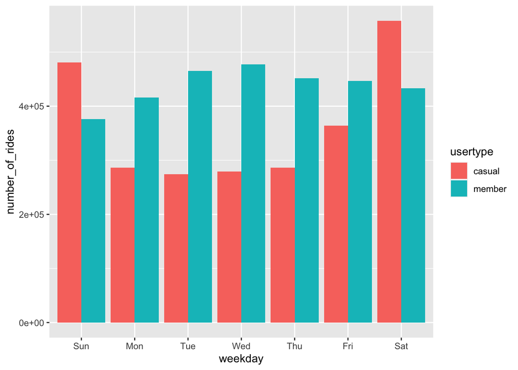

```r
rideshare2021_v2 %>%
  mutate(weekday = wday(started_at, label = TRUE)) %>%
  group_by(usertype, weekday) %>%
  summarize(number_of_rides = n()
            ,average_duration = mean(ride_length)) %>%
  arrange(usertype, weekday) %>%
  ggplot(aes(x = weekday, y = number_of_rides, fill = usertype))+ ## Plot number of rides for each weekday with fill visualization of usertype
  geom_col(position="dodge")
```

It becomes very clear that casual rides peak their usage on the weekends, Friday through Sunday, while the annual members peak mid-week. Let’s also take a look at the average trip duration in relation to the weekday:

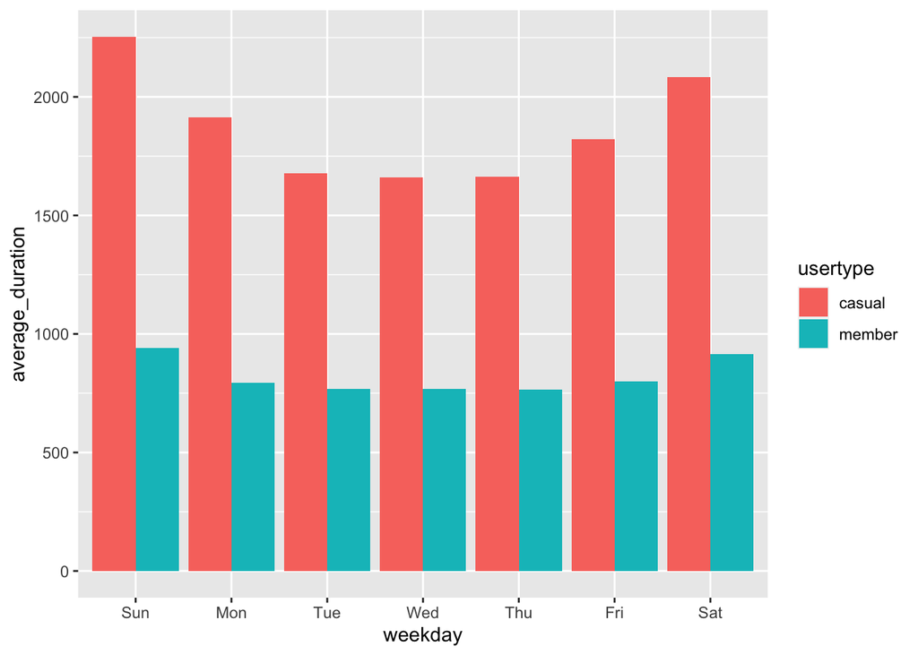

#### Bike Preferences

Comparing the average duration of a trip to the weekday shows clear evidence that casual riders prefer longer duration trips. Let’s also take a look at bike preferences.

```r
rideshare2021_v2 %>%
  group_by(usertype, bike_type) %>%
  tally() ## Count occurences
```

```
## # A tibble: 6 × 3
## # Groups:   usertype [2]
##   usertype bike_type           n
##   <chr>    <chr>           <int>
## 1 casual   classic_bike  1266629
## 2 casual   docked_bike    312337
## 3 casual   electric_bike  949980
## 4 member   classic_bike  1984314
## 5 member   docked_bike         1
## 6 member   electric_bike 1081655
```

```r
rideshare2021_v2 %>%
  group_by(usertype, bike_type) %>%
  tally() %>% ## Count occurences
  ggplot(aes(x = bike_type, y = n, fill = usertype))+
  geom_col(position="dodge")
```

[output not shown]

```r
rideshare2021_v2 %>%
  mutate(weekday = wday(started_at, label = TRUE)) %>%  ## Create weekday column
  filter (usertype == "casual") %>%  ## Only casual rider data
  group_by(weekday, bike_type) %>% ## Added bike_type
  summarize(number_of_rides = n()) %>%  ## Total rides
  arrange(weekday)
```

```
## # A tibble: 21 × 3
## # Groups:   weekday [7]
##    weekday bike_type     number_of_rides
##    <ord>   <chr>                   <int>
##  1 Sun     classic_bike           257516
##  2 Sun     docked_bike             70431
##  3 Sun     electric_bike          153157
##  4 Mon     classic_bike           135908
##  5 Mon     docked_bike             36445
##  6 Mon     electric_bike          114020
##  7 Tue     classic_bike           125927
##  8 Tue     docked_bike             29628
##  9 Tue     electric_bike          118833
## 10 Wed     classic_bike           131652
## # … with 11 more rows
```

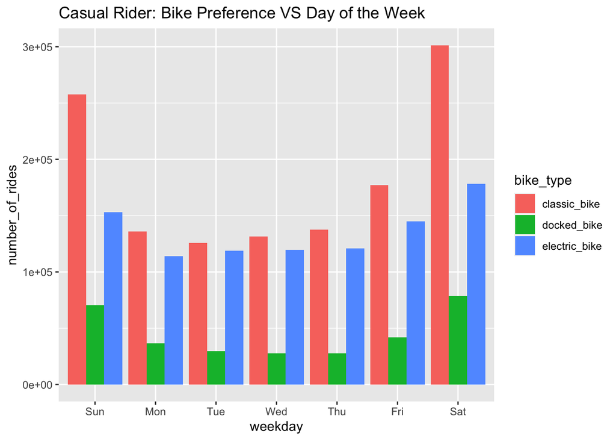

```r
rideshare2021_v2 %>%
  mutate(weekday = wday(started_at, label = TRUE)) %>%  ## Create weekday column
  filter (usertype == "casual") %>%  ## Only casual rider data
  group_by(weekday, bike_type) %>% ## Added bike_type
  summarize(number_of_rides = n()) %>%  ## Total rides
  arrange(weekday) %>%
  ggplot(aes( x = weekday, y = number_of_rides, fill = bike_type))+
  geom_col(position="dodge")+
  labs(title="Casual Rider: Bike Preference VS Day of the Week") ## Graph title
```

## Initial Findings

So far, I’ve been able to identify that casual riders prefer:

- Longer duration trips
- Weekend rides (Friday through Sunday)
- Classic Bikes

This is a great start to understanding the behavior of casual riders in 2021. Now that my data set has been cleaned, organized, and analyzed, I’ll write an export script for rideshare2021_v2 to conduct further analysis and visualization.

```r
write.csv(rideshare2021_v2, "rideshare2021_v2.csv")
```